# Comparison of road traffic accidents between USA and Singapore in 2022 and 2023

# 1 Aims, objectives and background

## 1.1 Introduction

Road traffic accidents are a critical issue worldwide, contributing to significant fatalities, injuries, and economic costs. The nature and frequency of these accidents vary widely across different countries due to factors such as infrastructure, traffic laws, and vehicle density. This project aims to analyse and compare road traffic accidents between the United States and Singapore; two countries with distinct traffic systems, urban layouts, and safety regulations. By drawing insights and consolidating traffic data from both nations, the project seeks to use data analysis to uncover patterns, risk factors, and opportunities for improving road safety globally as a result of my findings.

**Research Question:**

How do the underlying causes and proportions of fatal traffic accidents, specifically related to speeding and drink driving, differ between the United States and Singapore, and what insights can be drawn to inform effective road safety interventions tailored to varying national contexts?

## 1.2 Aims and objectives

I would like to explore the following in this project:

**Different causes leading to fatal traffic accidents**

- Weather & climate (seasonal vs tropical climate)
- Behavioural factors
- Geographic distribution (urban vs rural areas)

**Using the above key points I would like to explore further:**

- Identify key factors contributing to fatal road accidents in the United States and Singapore, with a focus on speeding and drink driving.
- Compare the proportions of these factors across the two countries using exploratory data analysis and visualization.
- Analyze trends in accident causes to help understand the role of enforcement, infrastructure, and cultural factors.
- Leverage data insights to propose effective, evidence-based road safety interventions tailored to each national context.
- Assess how weather conditions may influence road accident trends in both countries, particularly the role of precipitation."

**For this project proposal, my aims are to:**

1. Decide how much data is required to sufficiently explore the above questions, taking into consideration constraints on time and resource
2. Decide which publications and articles should be used to allow for a coherent analysis
3. Collect the data via webscraping and store in a form which allows for data cleaning and analysis
4. Clean and transform the data such that it is suitable for use in the techniques I would like to utilise later
5. Carry out some exploratory data analysis to identify that there are trends within the data which make it viable for further exploration

## 1.3 Data

#### 1.3.1 Data requirements

To carry out the comparison of road traffic accidents between the United States and Singapore, data requirements were defined based on the objectives of the project. Specifically, the following categories of data were identified as necessary:

- **Frequency and Severity of Traffic Accidents:** Data on the number of accidents, categorized by fatal and non-fatal incidents, across both countries.
- **Causes of Accidents:** Data highlighting factors such as speeding, distracted driving, intoxication, and violations of traffic laws.
- **Weather Conditions:** Information on weather-related accidents (e.g., snow, rain, fog for the US vs. wet/dry weather for Singapore).
- **Geographic Distribution:** Urban versus rural accident statistics.
- **Behavioral Factors:** Data on human error, adherence to traffic laws, and other driver behaviors.

The datasets used in this study will be selected based on their comprehensiveness, availability, and alignment with the research objectives. For the United States, data from the Fatality Analysis Reporting System (FARS) and National Centers for Environmental Information (NCEI) provided detailed accident statistics and weather data, respectively. For Singapore, consolidated reports from the Traffic Police and weather summaries from the Meteorological Service Singapore were utilized. These datasets were chosen to ensure consistency in comparing key metrics, such as speeding and drink-driving fatalities, alongside contextual weather data.

#### 1.3.2 Data sources

Primary sources of data will include:

1. **Publicly Available Government Reports:**
- United States: National Highway Traffic Safety Administration (NHTSA), Federal Highway Administration (FHWA).
- Singapore: Singapore Land Transport Authority (LTA), Traffic Police Department reports.
2. **Data Portals:**
- US: Data.gov, National Motor Vehicle Crash Causation Survey.
- Singapore: Government datasets on data.gov.sg.
3. **Third-party Sources:**
- WHO Global Status Report on Road Safety.
- Research articles and datasets from safety institutions.

#### 1.3.3 Methodology for data collection

The datasets will be collected using:

- **Web scraping:** For publicly available reports and data, tools such as Python's requests and BeautifulSoup will be utilized.
- **APIs:** Where available (e.g., Data.gov), APIs will be used for efficient data retrieval.
- **Manual download and cleaning:** Datasets available in static formats (e.g., CSV, XLS) will be downloaded and prepared for analysis.

#### 1.3.4 Limitations and constraints of the data

Despite its strengths, this study acknowledges several limitations. The US data covers a larger geographical area with diverse conditions, making direct comparisons with Singapore's urban-centric environment challenging. Furthermore, Singapore's data, derived from annual reports, lacks granular detail, such as exact accident locations or real-time weather conditions. These constraints necessitate careful interpretation, ensuring insights are contextualized within each country's unique demographic and environmental factors. Nonetheless, the selected datasets provide a robust foundation for addressing the research question.

## 1.4 Ethical Considerations

#### 1.4.1 Data usage and privacy

This study adheres to ethical guidelines by utilizing publicly available and anonymized traffic data. All datasets respect the terms of use and do not include personally identifiable information. Efforts have been made to attribute sources accurately and highlight the limitations of the data to avoid misleading interpretations. By focusing on objective analysis, this project minimizes the risk of perpetuating harmful stereotypes or assumptions.

#### 1.4.2 Copyright and permissions

Even though there is no intention to use private datasets, permissions to use data, where required, will be obtained:

- US datasets from government portals are generally public domain.
- Singaporean datasets will follow the open-data license stipulated on data.gov.sg.

#### 1.4.3 Limitations in interpretations

This project acknowledges the ethical responsibility of avoiding overgeneralizations or misinterpretations of data. The findings will be reported with clarity about their scope and limitations.

#### 1.4.4 Potential impacts

The insights derived from this project aim to contribute to global road safety improvement efforts. Care will be taken to avoid presenting data or results in a manner that could be misused for political or commercial purposes.

```python
#Import all necessary libraries
!pip install pymupdf
!pip install selenium
!pip install requests-html
!pip install lxml[html_clean]
!pip install requests beautifulsoup4 pandas
!pip install PyPDF2
!pip install python-docx
```

[output not shown]

[output cut: 84 more lines]

[output not shown]

# 2 Methodology for Data Collection and Standardization

### 2.1 Overview

This section outlines the data sources, collection methods, and steps taken to standardize the data for analyzing traffic accidents in the United States and Singapore. Emphasis is placed on extracting insights into fatal and non-fatal accidents, their frequency, and contributing factors.

### 2.2 Data Sources

The data for this section was sourced from two primary repositories: the Insurance Institute for Highway Safety (IIHS) for U.S. traffic statistics and Singapore's Traffic Police annual reports. The IIHS data provides comprehensive coverage of crash characteristics, while the Singapore reports offer insights into traffic accidents within a densely urbanized context. These sources were chosen for their relevance to the research question, as they provide detailed metrics on speeding and drink-driving fatalities, allowing for a comparative analysis of underlying factors influencing traffic accidents in two distinct national contexts.

#### 2.2.1 United States

**1. Federal Highway Administration (FHWA):**

Road traffic data related to fatalities and injuries, sourced from FHWA's public records.

```python
import pandas as pd

# File path for the FHWA data
fhwa_data_path = r'SourceData\FHWAData.txt'

# Load the FHWA data with a tab delimiter
fhwa_data = pd.read_csv(fhwa_data_path, delimiter='\t')

# Filter out header rows using the 'isHeader' column
fhwa_data_filtered = fhwa_data[fhwa_data['isHeader'] == 0].copy()

# Keep only relevant rows
relevant_rows = ['Fatal Crashes', 'Fatalities per 100 Million Vehicle Miles Traveled']
fhwa_data_filtered = fhwa_data_filtered[fhwa_data_filtered['colname'].isin(relevant_rows)]

# Identify year columns
year_columns = [col for col in fhwa_data_filtered.columns if col.isdigit() and int(col) >= 2022]

# Melt the dataset
fhwa_melted = fhwa_data_filtered.melt(
    id_vars=['colname'],
    value_vars=year_columns,
    var_name='Year',
    value_name='Value'
)

# Pivot and standardize
fhwa_summary = fhwa_melted.pivot(index='Year', columns='colname', values='Value').reset_index()
fhwa_summary.columns.name = None
fhwa_summary = fhwa_summary.rename(columns={
    'Fatal Crashes': 'Fatal Accidents',
    'Fatalities per 100 Million Vehicle Miles Traveled': 'Fatalities per 100M VMT'
})
fhwa_summary['Country'] = 'USA'
fhwa_summary['Month'] = 'Annual'
fhwa_summary = fhwa_summary[['Year', 'Month', 'Country', 'Fatal Accidents']]

# Add placeholder for Non-Fatal Accidents
fhwa_summary['Non-Fatal Accidents'] = None

# Save to CSV
fhwa_output_path = r'DataOutputs\fhwa_standardized_data.csv'
fhwa_summary.to_csv(fhwa_output_path, index=False)
```

**2.National Highway Traffic Safety Administration (NHTSA):**

Early estimates of motor vehicle traffic fatalities for the first nine months of 2024, detailed in an official PDF report.

```python
import docx
import pandas as pd
import re

# File path for the Word document
word_doc_path = r'SourceData\NHTSA_data.docx'

def extract_full_year_fatalities(doc_path):
    # Load the Word document
    doc = docx.Document(doc_path)

    # Extract text from the document
    text = "\n".join([p.text for p in doc.paragraphs if p.text.strip()])

    # Regex to capture year and full year total fatalities
    pattern = r"(202[2-4])\s+\d{1,3},\d{3}\s+\[\s*[+-]?\d+\.?\d*%\s*\]\s+\d{1,3},\d{3}\s+\[\s*[+-]?\d+\.?\d*%\s*\]\s+\d{1,3},\d{3}\s+\[\s*[+-]?\d+\.?\d*%\s*\]\s+\d{1,3},\d{3}\s+\[\s*[+-]?\d+\.?\d*%\s*\]\s+(\d{1,3},\d{3})"
    matches = re.findall(pattern, text)

    # Process matches into a structured format
    data = []
    for year, fatalities in matches:
        data.append({
            "Year": int(year),
            "Month": "Annual",
            "Country": "USA",
            "Fatal Accidents": int(fatalities.replace(",", "")),
            "Non-Fatal Accidents": 0  # Placeholder value
        })

    # Create DataFrame
    fatalities_df = pd.DataFrame(data)

    return fatalities_df

# Extract data
nhtsa_fatalities_df = extract_full_year_fatalities(word_doc_path)

# Save to CSV
output_path = r'DataOutputs\nhtsa_full_year_fatalities.csv'
nhtsa_fatalities_df.to_csv(output_path, index=False)
```

#### 2.2.2 Singapore

**1. Land Transport Authority (LTA):**

Annual and monthly data on road traffic accident casualties, including breakdowns by fatality and injury severity.

```python
import pandas as pd

# File paths
annual_data_path = r'SourceData\RoadTrafficAccidentCasualtiesAnnual.csv'
monthly_data_path = r'SourceData\RoadTrafficAccidentCasualtiesMonthly.csv'

# Load datasets
annual_data = pd.read_csv(annual_data_path)
monthly_data = pd.read_csv(monthly_data_path)

# Process annual data
annual_data_melted = annual_data.melt(id_vars=['DataSeries'], var_name='Year', value_name='Value')
required_series = ['Total Casualties Fatalities']
annual_data_filtered = annual_data_melted[
    (annual_data_melted['DataSeries'].isin(required_series)) &
    (annual_data_melted['Year'].astype(int) >= 2022)
]
annual_summary = annual_data_filtered.pivot(index='Year', columns='DataSeries', values='Value').reset_index()
annual_summary = annual_summary.rename(columns={"Total Casualties Fatalities": "Fatal Accidents"})
annual_summary['Country'] = 'Singapore'
annual_summary['Month'] = 'Annual'

# Process monthly data
monthly_data_melted = monthly_data.melt(id_vars=['DataSeries'], var_name='MonthYear', value_name='Value')
monthly_data_filtered = monthly_data_melted.loc[
    (monthly_data_melted['DataSeries'].isin(required_series)) &
    (monthly_data_melted['MonthYear'].str.contains('202[2-9]'))
].copy()  # Use .copy() to avoid modifying a slice

# Extract Year and Month
monthly_data_filtered.loc[:, 'Year'] = monthly_data_filtered['MonthYear'].str.extract(r'(202\d)')
monthly_data_filtered.loc[:, 'Month'] = monthly_data_filtered['MonthYear'].str.extract(r'([A-Za-z]+)')
monthly_summary = monthly_data_filtered.pivot_table(
    index=['Year', 'Month'], columns='DataSeries', values='Value', aggfunc='sum'
).reset_index()
monthly_summary = monthly_summary.rename(columns={"Total Casualties Fatalities": "Fatal Accidents"})
monthly_summary['Country'] = 'Singapore'

# Combine datasets
combined_data = pd.concat([annual_summary, monthly_summary], ignore_index=True)
combined_data = combined_data[['Year', 'Month', 'Country', 'Fatal Accidents']]
combined_data['Non-Fatal Accidents'] = None

# Save to CSV
sg_lta_output_path = r'Dataoutputs\sg_standardized_accident_data.csv'
combined_data.to_csv(sg_lta_output_path, index=False)
```

### 2.3 Data Collection and Preprocessing for later analysis

Preprocessing of the data involved handling missing values by imputation or removal, ensuring consistency across metrics. For instance, numeric fields were validated using regular expressions to eliminate non-numeric characters, and missing values for key fields like accident counts were filled using domain-appropriate estimates where possible. Additionally, datasets were formatted into a unified structure, enabling direct comparisons of metrics such as fatal accident proportions.

#### 2.3.3 Singapore Traffic Data

- **Sources:**CSV files and a PDF report were utilized to collect data on fatal and non-fatal accidents.
- **Integration:**The data was consolidated and filtered to include entries from 2022 onward, ensuring relevance to the study period.

### 2.4 Summary of Standardized Data

```python
import pandas as pd

# File paths for the standardized data
sg_data_path = r'DataOutputs\sg_standardized_accident_data.csv'
nhtsa_data_path = r'DataOutputs\nhtsa_full_year_fatalities.csv'
fhwa_data_path = r'DataOutputs\fhwa_standardized_data.csv'
sg_crash_data_path = r'DataOutputs\sg_crash_data.csv'

# Load the standardized datasets
sg_data = pd.read_csv(sg_data_path)
nhtsa_data = pd.read_csv(nhtsa_data_path)
fhwa_data = pd.read_csv(fhwa_data_path)
sg_crash_data = pd.read_csv(sg_crash_data_path)

# Ensure all datasets have standard columns
datasets = [sg_data, nhtsa_data, fhwa_data, sg_crash_data]

# Define the standard columns
standard_columns = ['Year', 'Month', 'Country', 'Fatal Accidents', 'Non-Fatal Accidents']

# Process each dataset
processed_datasets = []
for df in datasets:
    # Ensure the dataset has the standard columns
    for col in standard_columns:
        if col not in df.columns:
            df[col] = None  # Add missing columns as placeholders
    # Keep only standard columns
    df = df[standard_columns]
    processed_datasets.append(df)

# Merge all datasets into one
combined_data = pd.concat(processed_datasets, ignore_index=True)

# Clean and aggregate the data by Year and Country
aggregated_data = combined_data.groupby(['Year', 'Country'], as_index=False).agg({
    'Fatal Accidents': 'sum',
    'Non-Fatal Accidents': 'sum'
})

# Save the cleaned and aggregated dataset to a CSV
output_path = r'ComparisonData\aggregated_fatal_accidents_data.csv'
aggregated_data.to_csv(output_path, index=False)
```

### 2.5 Limitations of gathered data

While the datasets provide valuable insights, they have inherent limitations. Both the U.S. and Singapore datasets cover only two years (2022 and 2023), which may limit the ability to identify long-term trends. Additionally, the Singapore dataset is more aggregated, lacking the granular details available in the U.S. data. Despite these limitations, the selected datasets remain well-suited for exploring the immediate research question, given their relevance and the richness of the available metrics.

# 3 Data for Comparative Analysis

### 3.1 Collecting Comparison Data

This section focuses on collecting additional datasets to enhance the comparative analysis of traffic accidents in the US and Singapore. Key areas of exploration include behavioral factors influencing accidents, the role of weather and climate in road safety, and the impact of speed limits. These data points will provide a richer context for understanding the differences and similarities in traffic accident trends between the two nations. Leveraging data from authoritative sources, the aim is to uncover patterns and correlations that can inform actionable insights into road safety policies and practices.

### 3.2 Behavioral Factors

**Objective:** Collect data on behavioral causes of traffic accidents for the US and Singapore.

I will be limiting these factors into the following categories as toon many variables will overcrowd the later exploratory analysis.

**Factors Include:**

- Drink Driving
- Speeding

#### 3.2.1 US Behavioral Data

- **Sources:** National Motor Vehicle Crash Causation Survey (NMVCCS)
- **Methodology:**
  - Web scraping or API usage for FARS database.
  - Extract relevant behavioral factors (e.g., alcohol use, seatbelt compliance, phone use).

**Drink Driving Data gathering:**

```python
import requests
from bs4 import BeautifulSoup
import pandas as pd

# URL of the IIHS speeding data page
url = "https://www.iihs.org/topics/fatality-statistics/detail/alcohol"

# Send a GET request to fetch the webpage content
response = requests.get(url)
if response.status_code != 200:
    print(f"Failed to fetch webpage: {response.status_code}")
    exit()

# Parse the webpage content with BeautifulSoup
soup = BeautifulSoup(response.content, "html.parser")

# Locate the table dynamically by searching for keywords in the title
table = None
for div in soup.find_all("div", class_="table"):
    title = div.find("th", class_="table-title")
    if title and "Estimated number and percent of fatally injured people with BACs" in title.text:
        table = div
        break

if not table:
    print("Failed to find the alcohol-related data table on the page.")
    exit()

# Extract table headers
headers = [th.text.strip() for th in table.find_all("th") if th.text.strip()]

# Extract table rows
rows = []
for row in table.find_all("tr")[2:]:  # Skip the first two header rows
    cols = row.find_all("td")
    year_col = row.find("th")  # Year is stored in a 'th' element
    if year_col and cols:
        year = year_col.text.strip()
        row_data = [year] + [col.text.strip().replace(",", "") for col in cols]
        rows.append(row_data)

# Convert the extracted data into a DataFrame
columns = ["Year", "All Drivers (Deaths)", "All Drivers (BAC ≥ 0.08, Number)", "All Drivers (BAC ≥ 0.08, %)",
           "Passenger Vehicle Drivers (Deaths)", "Passenger Vehicle Drivers (BAC ≥ 0.08, Number)", "Passenger Vehicle Drivers (BAC ≥ 0.08, %)",
           "Large Truck Drivers (Deaths)", "Large Truck Drivers (BAC ≥ 0.08, Number)", "Large Truck Drivers (BAC ≥ 0.08, %)",
           "Motorcycle Drivers (Deaths)", "Motorcycle Drivers (BAC ≥ 0.08, Number)", "Motorcycle Drivers (BAC ≥ 0.08, %)",
           "Pedestrians (Deaths)", "Pedestrians (BAC ≥ 0.08, Number)", "Pedestrians (BAC ≥ 0.08, %)"]
alcohol_data = pd.DataFrame(rows, columns=columns)

# Filter for years 2022 and 2023
alcohol_data = alcohol_data[alcohol_data["Year"].isin(["2022", "2023"])]

# Convert numeric columns to integers or floats
numeric_columns = columns[1:]  # All columns except "Year"
for col in numeric_columns:
    alcohol_data[col] = pd.to_numeric(alcohol_data[col], errors="coerce")

# Save the extracted data to a CSV file
output_path = r"DataOutputs\iihs_alcohol_data_2022.csv"
alcohol_data.to_csv(output_path, index=False)
```

Due to an absence of 2023 data in the IIHS report, i will be performing further webscraping to gather statistics for 2023.

```python
import requests
from bs4 import BeautifulSoup
import pandas as pd
url = "https://drugabusestatistics.org/alcohol-related-deaths/"
headers = {"User-Agent": "Mozilla/5.0"}  # Helps prevent blocking by some servers
response = requests.get(url, headers=headers)
if response.status_code != 200:
    print(f"Failed to fetch webpage: {response.status_code}")
    exit()
soup = BeautifulSoup(response.content, "html.parser")
# Find the section header
section_header = soup.find(lambda tag: tag.name == "h2" and "Drunk Driving Fatalities" in tag.text)
if not section_header:
    print("Failed to find the 'Drunk Driving Fatalities' section.")
    exit()

# The table is likely located after this header
table = section_header.find_next("table")
if not table:
    print("Failed to find the table following the 'Drunk Driving Fatalities' section.")
    exit()
# Extract headers
headers = [th.text.strip() for th in table.find_all("th")]

# Extract rows
rows = []
for tr in table.find_all("tr")[1:]:  # Skip the header row
    cols = tr.find_all(["td", "th"])
    row = [col.text.strip().replace(",", "") for col in cols]
    rows.append(row)
# Create DataFrame
drunk_driving_data = pd.DataFrame(rows, columns=headers)

# Convert numeric columns to appropriate data types
for col in drunk_driving_data.columns[1:]:  # Assuming the first column is 'State' or 'Year'
    drunk_driving_data[col] = pd.to_numeric(drunk_driving_data[col], errors="coerce")
output_path = "DataOutputs/ncdas_drunk_driving_data_2023.csv"
drunk_driving_data.to_csv(output_path, index=False)
```

**Speeding Data gathering:**

```python
import requests
from bs4 import BeautifulSoup
import pandas as pd

# URL of the IIHS speeding data page
url = "https://www.iihs.org/topics/fatality-statistics/detail/yearly-snapshot#speeding"

# Send a GET request to fetch the webpage content
response = requests.get(url)
if response.status_code != 200:
    print(f"Failed to fetch webpage: {response.status_code}")
    exit()

# Parse the webpage content with BeautifulSoup
soup = BeautifulSoup(response.content, "html.parser")

# Locate the table dynamically by searching for keywords in the title
table = None
for div in soup.find_all("div", class_="table"):
    title = div.find("th", class_="table-title")
    if title and "Motor vehicle crash deaths involving speeding" in title.text:
        table = div
        break

if not table:
    print("Failed to find the speeding data table on the page.")
    exit()

# Extract table headers
headers = [th.text.strip() for th in table.find_all("th") if th.text.strip()]

# Extract table rows
rows = []
for row in table.find_all("tr")[2:]:  # Skip the first two header rows
    cols = row.find_all("td")
    year_col = row.find("th")  # Year is stored in a 'th' element
    if year_col and cols:
        year = year_col.text.strip()
        row_data = [year] + [col.text.strip().replace(",", "") for col in cols]
        rows.append(row_data)

# Convert the extracted data into a DataFrame
columns = ["Year", "Speeding-Related (Number)", "Speeding-Related (%)",
           "Not Speeding-Related (Number)", "Not Speeding-Related (%)", "Total"]
speeding_data = pd.DataFrame(rows, columns=columns)

# Convert numeric columns to integers or floats
numeric_columns = ["Speeding-Related (Number)", "Speeding-Related (%)",
                   "Not Speeding-Related (Number)", "Not Speeding-Related (%)", "Total"]
for col in numeric_columns:
    speeding_data[col] = pd.to_numeric(speeding_data[col], errors="coerce")

# Save the extracted data to a CSV file
output_path = r"DataOutputs\iihs_speeding_data.csv"
speeding_data.to_csv(output_path, index=False)
```

For this part, I have webscraped the data from the IIHS website that includes accident statistics pertaining to speeding across the years.

#### 3.2.2 Singapore Behavioral Data

- **Source:** Traffic Police Reports, Land Transport Authority (LTA).
- **Methodology:**
  - Extract data from uploaded Traffic Police PDF.
  - Process insights manually or programmatically (e.g., text extraction for contributing factors).

The PDF report from the Singapore Police Force provides both speeding and drink driving statistics in their publications. I will be using the PDF to extract the data statistics.

**Speeding:**

```python
import fitz  # PyMuPDF
import re
import pandas as pd

# Load the PDF file
pdf_path = r'SourceData/PNR Annual Road Traffic Situation 2023.pdf'
doc = fitz.open(pdf_path)

# Variables to store extracted data
data = []

# Define a regex pattern to match the paragraphs of interest
pattern = r"(fatal accidents due to speeding.*?increased.*?from\s+(\d+)\s+cases.*?(\d+)\s+cases.*?2022.*?2023)"

# Iterate through the pages and extract relevant text
for page in doc:
    text = page.get_text()
    matches = re.findall(pattern, text, re.IGNORECASE | re.DOTALL)
    for match in matches:
        data.append({
            "Description": match[0],
            "Year 2022": int(match[1]),
            "Year 2023": int(match[2])
        })

# Convert extracted data into a DataFrame
df = pd.DataFrame(data)

# Save the extracted data to a CSV file
output_csv = r'DataOutputs\speeding_fatal_accidents_SG.csv'
df.to_csv(output_csv, index=False)
```

**Drunk Driving:**

```python
import fitz  # PyMuPDF
import re
import pandas as pd

# Load the PDF file
pdf_path = r'SourceData\PNR Annual Road Traffic Situation 2023.pdf'
doc = fitz.open(pdf_path)

# Variables to store extracted data
data = []

# Define a regex pattern to match the drink-driving fatal accident data
pattern = r"fatal drink-driving accidents.*?increased.*?from\s+(\d+)\s+cases.*?to\s+(\d+)\s+cases.*?2022.*?2023"

# Iterate through the pages and extract relevant text
for page in doc:
    text = page.get_text()
    matches = re.findall(pattern, text, re.IGNORECASE | re.DOTALL)
    for match in matches:
        data.append({
            "Description": "Fatal Drink-Driving Accidents",
            "Year 2022": int(match[0]),
            "Year 2023": int(match[1])
        })

# Convert extracted data into a DataFrame
df = pd.DataFrame(data)

# Save the extracted data to a CSV file
output_csv = r'DataOutputs\fatal_drink_driving_accidents_SG.csv'
df.to_csv(output_csv, index=False)
```

The provided code employs text extraction and regular expression matching to extract specific statistics (e.g., fatal drink-driving accidents) from a structured PDF report. This approach is well-suited for the report's context as it allows automated extraction of numerical data embedded in paragraphs, minimizing manual errors and saving time. By searching for specific keywords like "drink-driving" and applying regular expressions to capture numbers within relevant sentences, the code ensures precision in identifying and retrieving pertinent data.

This method is adaptable for future data extraction by modifying the keyword and regex patterns to match new metrics or report formats. Its flexibility allows it to handle updates in document structure or content focus, ensuring its ongoing utility in comparative analyses of traffic statistics.

### 3.3 Weather and Climate

**Objective:** Analyze the role of weather conditions on traffic accidents in the US and Singapore.

#### Weather Impact on Traffic Accidents

Weather conditions significantly influence road safety by affecting visibility, road surface conditions, and driver behavior. In tropical regions like Singapore, frequent rainfall can lead to slippery roads and reduced visibility, increasing accident risks. In contrast, the United States experiences a variety of weather patterns due to its diverse climate zones, including snow, ice, fog, and heavy rain, each presenting unique challenges to drivers.

#### Precipitation Data Comparison: 2022-2023

To understand the potential impact of weather on traffic accidents, I have directly sourced and collected data to compare the annual precipitation data for Singapore and the United States for the years 2022 and 2023.

**Singapore:**

- 2023: The annual total rainfall averaged across islandwide stations was 2,866.1 mm, which is 13.1% above the long-term average of 2,534.3 mm, making 2023 Singapore’s seventh wettest year since 1980.
- 2022: Specific data not provided in the source; however, the long-term average is 2,534.3 mm.

**United States:**

- 2023: The average annual precipitation was 29.46 inches (748.28 mm), which is 0.48 inches below the long-term average.
- 2022: Specific data not provided in the source; however, the long-term average is approximately 29.94 inches (760.98 mm).

#### Analysis

Singapore's consistently high annual rainfall, with a significant increase in 2023, could potentially be a factor of weather-related traffic accidents due to wet road conditions. In contrast, the United States shows relatively stable precipitation levels around the long-term average.

### 3.4 Consolidating Data

**Objective:** Combine the datasets from the above sections into a standardized CSV file.

**Code:**

```python
import pandas as pd

# Define all file paths
speeding_fatalities_sg_path = r'DataOutputs\speeding_fatal_accidents_SG.csv'
drink_driving_fatalities_sg_path = r'DataOutputs\fatal_drink_driving_accidents_SG.csv'
iihs_alcohol_data_2022_path = r'DataOutputs\iihs_alcohol_data_2022.csv'
iihs_speeding_data_path = r'DataOutputs\iihs_speeding_data.csv'
ncdas_drunk_driving_data_2023_path = r'DataOutputs\ncdas_drunk_driving_data_2023.csv'  # Make sure this is correctly declared

# Load datasets
speeding_sg = pd.read_csv(speeding_fatalities_sg_path)
drink_driving_sg = pd.read_csv(drink_driving_fatalities_sg_path)
iihs_alcohol_2022 = pd.read_csv(iihs_alcohol_data_2022_path)
iihs_speeding = pd.read_csv(iihs_speeding_data_path)
ncdas_drunk_driving_2023 = pd.read_csv(ncdas_drunk_driving_data_2023_path)  # This will now work

# Extract data
# USA drink-driving fatalities (2022)
usa_alcohol_2022 = iihs_alcohol_2022.loc[
    iihs_alcohol_2022['Year'] == 2022, 'All Drivers (BAC ≥ 0.08, Number)'
].values[0]

# USA drink-driving fatalities (2023)
usa_drunk_driving_2023 = ncdas_drunk_driving_2023['Number of Fatalities'].sum()

# USA speeding fatalities (2022)
usa_speeding_2022 = iihs_speeding.loc[
    iihs_speeding['Year'] == 2022, 'Speeding-Related (Number)'
].values[0]

# USA speeding fatalities (2023)
usa_speeding_2023 = 11768

# Singapore speeding fatalities (2022 and 2023)
sg_speeding_2022 = speeding_sg.loc[
    speeding_sg['Description'].str.contains('fatal accidents due to speeding', case=False, na=False),
    'Year 2022'
].values[0]
sg_speeding_2023 = speeding_sg.loc[
    speeding_sg['Description'].str.contains('fatal accidents due to speeding', case=False, na=False),
    'Year 2023'
].values[0]

# Singapore drink-driving fatalities (2022 and 2023)
sg_drink_driving_2022 = drink_driving_sg.loc[
    drink_driving_sg['Description'] == 'Fatal Drink-Driving Accidents',
    'Year 2022'
].values[0]
sg_drink_driving_2023 = drink_driving_sg.loc[
    drink_driving_sg['Description'] == 'Fatal Drink-Driving Accidents',
    'Year 2023'
].values[0]

# Consolidate data
consolidated_data = pd.DataFrame({
    'Year': [2022, 2022, 2023, 2023],
    'Country': ['USA', 'Singapore', 'USA', 'Singapore'],
    'Speeding Fatalities': [usa_speeding_2022, sg_speeding_2022, usa_speeding_2023, sg_speeding_2023],
    'Drink-Driving Fatalities': [usa_alcohol_2022, sg_drink_driving_2022, usa_drunk_driving_2023, sg_drink_driving_2023]
})

output_path = r'ComparisonData\consolidated_drunk-driving_speed_data.csv'
consolidated_data.to_csv(output_path, index=False)
```

To address the absence of directly available data for USA speeding fatalities in 2023, I utilized a calculation-based approach. According to publicly available data, speeding was a contributing factor in approximately 29% of all fatal accidents in the United States in 2023. By applying this percentage to the total number of traffic fatalities recorded for the year, I estimated the number of speeding-related fatalities to be around 11,768. This method allowed me to derive a reasonable estimate in line with the reported trends

### 3.5 Limitations

- **Behavioral Data:**
  - Lack of detailed behavioral factors in Singapore data compared to the US.
  - Reliance on manual extraction from reports for Singapore may introduce biases.
- **Weather Data:**
  - Weather data may not align perfectly with accident dates and locations.
  - Limited availability of detailed weather conditions for Singapore.
- **General Data Alignment:**
  - Inconsistencies in data availability and reporting standards between the US and Singapore pose challenges in drawing direct comparisons.
  - Comparisons drawn may not be very accurate, these limitations must be considered when interpreting findings.

# 4 Exploratory data analysis

### 4.1 Comparison of Speeding vs. Drink-Driving Fatalities Across Countries

- **Objective:**To compare the contributions of speeding and drink-driving fatalities for the US and Singapore in 2022 and 2023.
- **Graph Types:**Bar Charts, Pie Charts.
- **Insight:**Highlights which cause of fatalities is more dominant in each country and year.

#### 4.1.1 General Statistics

Due to the difference in sample size from the USA being significantly higher than Singapore, the graphs will be split up to each respective country. To interpret the full scope of the data gathered, a few graphs will be plotted to easily visualise the data.

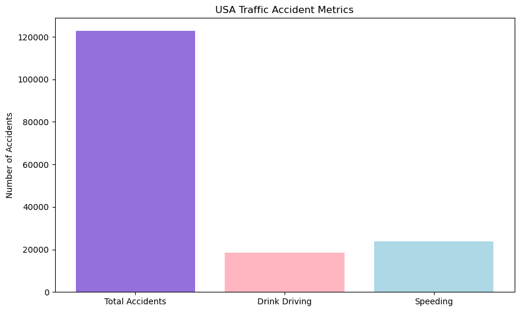

```python
import pandas as pd
import matplotlib.pyplot as plt

# Load datasets
aggregated_data = pd.read_csv(r'ComparisonData\aggregated_fatal_accidents_data.csv')
consolidated_data = pd.read_csv(r'ComparisonData\consolidated_drunk-driving_speed_data.csv')

# Filter data for the USA
usa_aggregated = aggregated_data[aggregated_data["Country"] == "USA"]
usa_consolidated = consolidated_data[consolidated_data["Country"] == "USA"]

# Extract relevant data
usa_total = usa_aggregated["Fatal Accidents"].sum()
usa_drink_driving = usa_consolidated["Drink-Driving Fatalities"].sum()
usa_speeding = usa_consolidated["Speeding Fatalities"].sum()

# Prepare data for bar graph
metrics = ["Total Accidents", "Drink Driving", "Speeding"]
values = [usa_total, usa_drink_driving, usa_speeding]

# Create bar graph
plt.figure(figsize=(10, 6))
plt.bar(metrics, values, color=["MediumPurple", "lightpink", "lightblue"])
plt.title("USA Traffic Accident Metrics")
plt.ylabel("Number of Accidents")
plt.show()
```

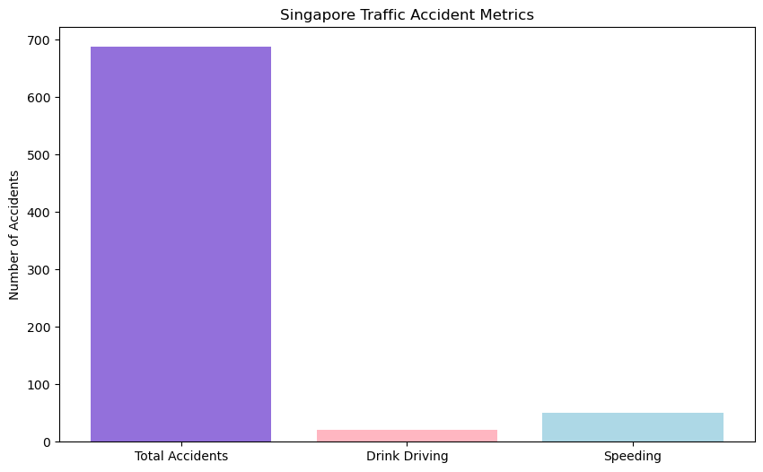

```python
# Filter data for Singapore
sg_aggregated = aggregated_data[aggregated_data["Country"] == "Singapore"]
sg_consolidated = consolidated_data[consolidated_data["Country"] == "Singapore"]

# Extract relevant data
sg_total = sg_aggregated["Fatal Accidents"].sum()
sg_drink_driving = sg_consolidated["Drink-Driving Fatalities"].sum()
sg_speeding = sg_consolidated["Speeding Fatalities"].sum()

# Prepare data for bar graph
metrics = ["Total Accidents", "Drink Driving", "Speeding"]
values = [sg_total, sg_drink_driving, sg_speeding]

# Create bar graph
plt.figure(figsize=(10, 6))
plt.bar(metrics, values, color=["MediumPurple", "lightpink", "lightblue"])
plt.title("Singapore Traffic Accident Metrics")
plt.ylabel("Number of Accidents")
plt.show()
```

From the bar graphs, it is evident that speeding is a more prevalent factor contributing to fatal traffic accidents compared to drink driving in both the USA and Singapore. This trend suggests that excessive speeding remains a significant challenge in traffic safety across both nations, potentially due to differences in driving behavior, enforcement practices, or road design.

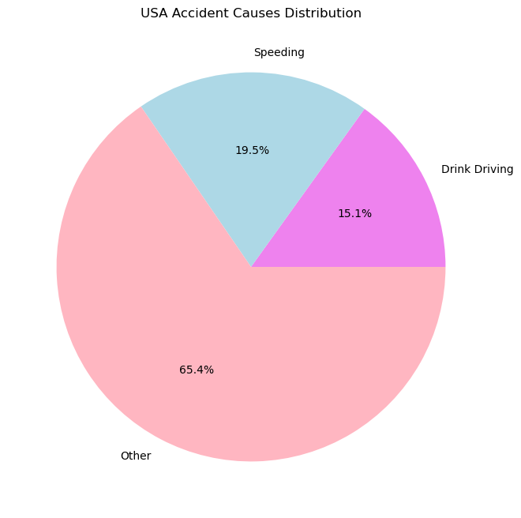

```python
# Prepare data for pie chart
usa_other = usa_total - (usa_drink_driving + usa_speeding)
pie_labels = ["Drink Driving", "Speeding", "Other"]
pie_values = [usa_drink_driving, usa_speeding, usa_other]

# Create pie chart
plt.figure(figsize=(8, 8))
plt.pie(pie_values, labels=pie_labels, autopct="%1.1f%%", colors=["violet", "lightblue", "lightpink"])
plt.title("USA Accident Causes Distribution")
plt.show()
```

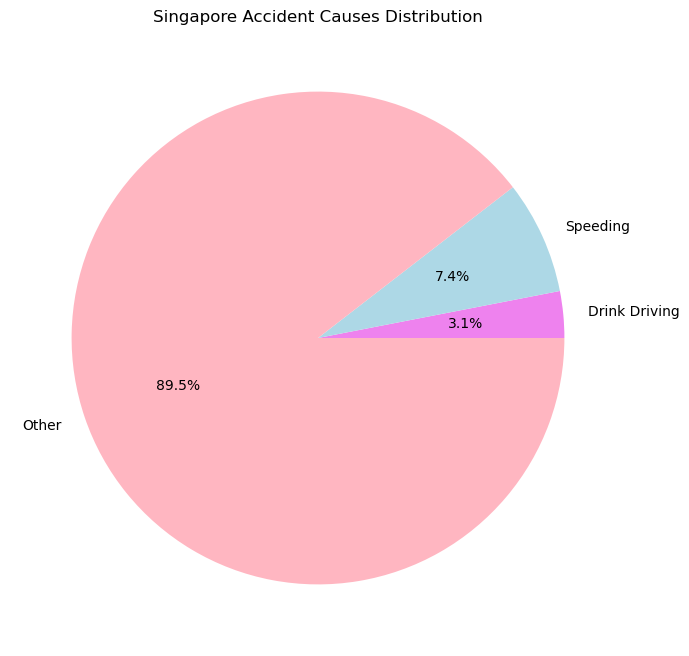

```python
# Prepare data for pie chart
sg_other = sg_total - (sg_drink_driving + sg_speeding)
pie_labels = ["Drink Driving", "Speeding", "Other"]
pie_values = [sg_drink_driving, sg_speeding, sg_other]

# Create pie chart
plt.figure(figsize=(8, 8))
plt.pie(pie_values, labels=pie_labels, autopct="%1.1f%%", colors=["violet", "lightblue", "lightpink"])
plt.title("Singapore Accident Causes Distribution")
plt.show()
```

**Summary:**

The analysis reveals significant differences in the proportions of fatal accidents caused by speeding and drink driving between the United States and Singapore, offering key insights into the research question. In the United States, these two factors account for a combined 34.6% of total fatalities, highlighting their substantial impact on road safety. In contrast, Singapore reports much lower proportions, with only 10.5% of fatalities attributed to these causes. This disparity underscores the influence of stricter traffic regulations, urban density, and cultural attitudes toward road safety in Singapore. These findings emphasize the need for tailored interventions, such as targeted campaigns against drink driving in the U.S. and addressing other causative factors in Singapore, to improve road safety outcomes in diverse national contexts.

#### 4.2.2 Temporal trends 2022-2023

Analyzing temporal trends in the data provides valuable insights into how accident-related factors such as speeding and drink driving evolve over time and differ between countries

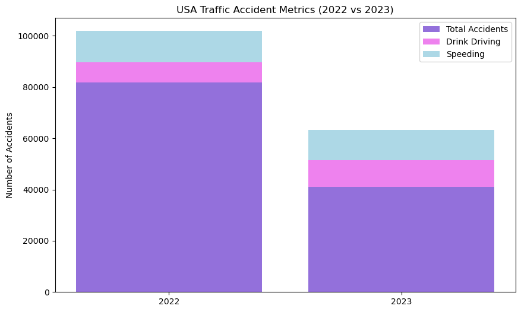

```python
# Filter data for the USA and split by year
usa_2022 = usa_aggregated[usa_aggregated["Year"] == 2022]["Fatal Accidents"].sum()
usa_2023 = usa_aggregated[usa_aggregated["Year"] == 2023]["Fatal Accidents"].sum()
usa_drink_driving_2022 = usa_consolidated[usa_consolidated["Year"] == 2022]["Drink-Driving Fatalities"].sum()
usa_drink_driving_2023 = usa_consolidated[usa_consolidated["Year"] == 2023]["Drink-Driving Fatalities"].sum()
usa_speeding_2022 = usa_consolidated[usa_consolidated["Year"] == 2022]["Speeding Fatalities"].sum()
usa_speeding_2023 = usa_consolidated[usa_consolidated["Year"] == 2023]["Speeding Fatalities"].sum()

# Prepare data for bar graph
years = ["2022", "2023"]
total_accidents = [usa_2022, usa_2023]
drink_driving = [usa_drink_driving_2022, usa_drink_driving_2023]
speeding = [usa_speeding_2022, usa_speeding_2023]

# Create bar graph
plt.figure(figsize=(10, 6))
plt.bar(years, total_accidents, color="MediumPurple", label="Total Accidents")
plt.bar(years, drink_driving, bottom=total_accidents, color="violet", label="Drink Driving")
plt.bar(years, speeding, bottom=[i + j for i, j in zip(total_accidents, drink_driving)], color="lightblue", label="Speeding")
plt.title("USA Traffic Accident Metrics (2022 vs 2023)")
plt.ylabel("Number of Accidents")
plt.legend()
plt.show()
```

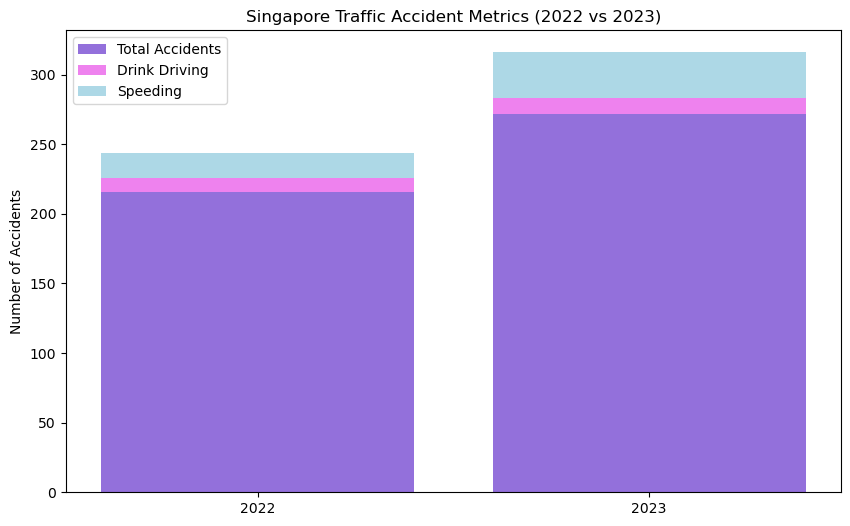

```python
# Filter data for Singapore and split by year
sg_2022 = sg_aggregated[sg_aggregated["Year"] == 2022]["Fatal Accidents"].sum()
sg_2023 = sg_aggregated[sg_aggregated["Year"] == 2023]["Fatal Accidents"].sum()
sg_drink_driving_2022 = sg_consolidated[sg_consolidated["Year"] == 2022]["Drink-Driving Fatalities"].sum()
sg_drink_driving_2023 = sg_consolidated[sg_consolidated["Year"] == 2023]["Drink-Driving Fatalities"].sum()
sg_speeding_2022 = sg_consolidated[sg_consolidated["Year"] == 2022]["Speeding Fatalities"].sum()
sg_speeding_2023 = sg_consolidated[sg_consolidated["Year"] == 2023]["Speeding Fatalities"].sum()

# Prepare data for bar graph
years = ["2022", "2023"]
total_accidents = [sg_2022, sg_2023]
drink_driving = [sg_drink_driving_2022, sg_drink_driving_2023]
speeding = [sg_speeding_2022, sg_speeding_2023]

# Create bar graph
plt.figure(figsize=(10, 6))
plt.bar(years, total_accidents, color="MediumPurple", label="Total Accidents")
plt.bar(years, drink_driving, bottom=total_accidents, color="violet", label="Drink Driving")
plt.bar(years, speeding, bottom=[i + j for i, j in zip(total_accidents, drink_driving)], color="lightblue", label="Speeding")
plt.title("Singapore Traffic Accident Metrics (2022 vs 2023)")
plt.ylabel("Number of Accidents")
plt.legend()
plt.show()
```

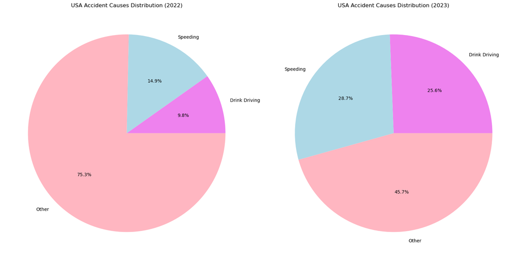

```python
# Calculate "Other" for each year
usa_other_2022 = usa_2022 - (usa_drink_driving_2022 + usa_speeding_2022)
usa_other_2023 = usa_2023 - (usa_drink_driving_2023 + usa_speeding_2023)

# Prepare data for pie charts
pie_labels = ["Drink Driving", "Speeding", "Other"]
values_2022 = [usa_drink_driving_2022, usa_speeding_2022, usa_other_2022]
values_2023 = [usa_drink_driving_2023, usa_speeding_2023, usa_other_2023]

# Create a figure with two subplots for the pie charts
fig, axes = plt.subplots(1, 2, figsize=(16, 8))

# Create pie chart for 2022
axes[0].pie(values_2022, labels=pie_labels, autopct="%1.1f%%", colors=["violet", "lightblue", "lightpink"])
axes[0].set_title("USA Accident Causes Distribution (2022)")

# Create pie chart for 2023
axes[1].pie(values_2023, labels=pie_labels, autopct="%1.1f%%", colors=["violet", "lightblue", "lightpink"])
axes[1].set_title("USA Accident Causes Distribution (2023)")

# Display the side-by-side pie charts
plt.tight_layout()
plt.show()
```

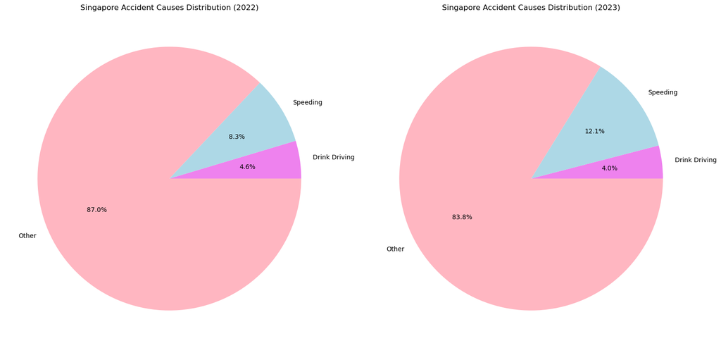

```python
import matplotlib.pyplot as plt

# Calculate "Other" for each year
sg_other_2022 = sg_2022 - (sg_drink_driving_2022 + sg_speeding_2022)
sg_other_2023 = sg_2023 - (sg_drink_driving_2023 + sg_speeding_2023)

# Prepare data for pie charts
pie_labels = ["Drink Driving", "Speeding", "Other"]
values_2022 = [sg_drink_driving_2022, sg_speeding_2022, sg_other_2022]
values_2023 = [sg_drink_driving_2023, sg_speeding_2023, sg_other_2023]

# Create a figure with two subplots for the pie charts
fig, axes = plt.subplots(1, 2, figsize=(16, 8))

# Create pie chart for 2022
axes[0].pie(values_2022, labels=pie_labels, autopct="%1.1f%%", colors=["violet", "lightblue", "lightpink"])
axes[0].set_title("Singapore Accident Causes Distribution (2022)")

# Create pie chart for 2023
axes[1].pie(values_2023, labels=pie_labels, autopct="%1.1f%%", colors=["violet", "lightblue", "lightpink"])
axes[1].set_title("Singapore Accident Causes Distribution (2023)")

# Display the side-by-side pie charts
plt.tight_layout()
plt.show()
```

**Pie Chart Summary**

The pie charts provide further insights into the proportional contributions of various factors to road fatalities. In the USA, the distribution reveals a notable shift in the impact of speeding and drink driving. In 2022, speeding accounted for 14.9% of fatalities and drink driving for 9.8%, contributing to a combined smaller share compared to other causes. By 2023, these factors became more dominant, with speeding increasing to 28.7% and drink driving to 25.6%, highlighting potential systemic challenges or enforcement gaps that may have emerged during this period.

In Singapore, however, the proportional contributions of these factors remain consistently low. In both 2022 and 2023, drink driving and speeding combined accounted for only 12.9% and 16.1% of total fatalities, respectively. This disparity may be attributed to Singapore's smaller and more controlled road network, coupled with strict enforcement of traffic regulations. The stark contrast between the USA and Singapore underscores how differing national contexts, such as road safety policies and traffic environments, influence the prevalence and management of these key risk factors.

**Summary:**

This breakdown of the data into years highlights the impact of Singapore's strict road safety laws and urban traffic environment in reducing fatalities from speeding and drink driving. In contrast, the higher proportions in the U.S. point to challenges with driving culture and law enforcement. These findings can be attributed to unique traffic conditions and culture in each country.

#### 4.2.3 Direct comparisons

In order to more directly gain insights on the differences in these speeding related data for the us and singapore, I will be drawing some line graphs for direct comparison. Due to the large sample size from the USA as compared to singapore, we will be comparing the percentage of the populations rather than the actual numbers to avoid discrepancy

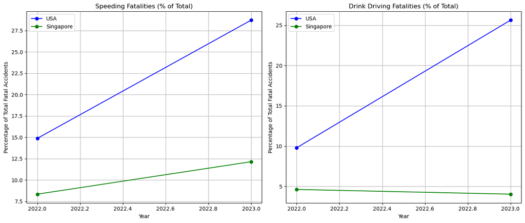

```python
import pandas as pd
import matplotlib.pyplot as plt

# Load the data
aggregated_data = pd.read_csv(r'ComparisonData\aggregated_fatal_accidents_data.csv')
consolidated_data = pd.read_csv(r'ComparisonData\consolidated_drunk-driving_speed_data.csv')

# Merge the datasets on 'Year' and 'Country'
merged_data = pd.merge(consolidated_data, aggregated_data, on=['Year', 'Country'], how='inner')

# Calculate percentages for speeding and drink-driving fatalities
merged_data['Speeding (%)'] = (merged_data['Speeding Fatalities'] / merged_data['Fatal Accidents']) * 100
merged_data['Drink Driving (%)'] = (merged_data['Drink-Driving Fatalities'] / merged_data['Fatal Accidents']) * 100

# Separate data by country
usa_data = merged_data[merged_data['Country'] == 'USA']
sg_data = merged_data[merged_data['Country'] == 'Singapore']

# Create a 1x2 grid for the line plots
fig, axes = plt.subplots(1, 2, figsize=(14, 6))

# Plot for Speeding (%)
axes[0].plot(usa_data['Year'], usa_data['Speeding (%)'], label='USA', marker='o', color='blue')
axes[0].plot(sg_data['Year'], sg_data['Speeding (%)'], label='Singapore', marker='o', color='green')
axes[0].set_title('Speeding Fatalities (% of Total)')
axes[0].set_xlabel('Year')
axes[0].set_ylabel('Percentage of Total Fatal Accidents')
axes[0].legend()
axes[0].grid()

# Plot for Drink Driving (%)
axes[1].plot(usa_data['Year'], usa_data['Drink Driving (%)'], label='USA', marker='o', color='blue')
axes[1].plot(sg_data['Year'], sg_data['Drink Driving (%)'], label='Singapore', marker='o', color='green')
axes[1].set_title('Drink Driving Fatalities (% of Total)')
axes[1].set_xlabel('Year')
axes[1].set_ylabel('Percentage of Total Fatal Accidents')
axes[1].legend()
axes[1].grid()

# Adjust spacing between graphs
plt.tight_layout()
plt.show()
```

The line graphs reveal stark differences between the United States and Singapore in the proportion of fatal accidents caused by speeding and drink driving, highlighting systemic variations in traffic safety challenges and enforcement.

#### 4.2.4 Further Analysis: Weather Trends and Their Impact on Traffic Accidents

**Other contributing factors**

Weather conditions play a crucial role in influencing traffic accident rates by altering road surface conditions, visibility, and driver behavior. The line graphs depicting speeding and drink-driving fatalities, when analyzed alongside weather trends, reveal complementary insights into the varying impacts of weather on traffic safety in Singapore and the United States.

In Singapore, where rainfall is consistently high, particularly in 2023 (with 2,866.1 mm, 13.1% above the long-term average), wet road conditions are a constant challenge for drivers. Despite this, the line graph shows relatively low proportions of fatalities attributed to speeding and drink driving compared to the U.S. This suggests that while adverse weather might increase general accident risks, Singapore’s strict enforcement of traffic laws and urban infrastructure mitigates the severity of high-risk driving behaviors such as speeding and drink driving. The notable increase in speeding-related fatalities in 2023 (from 8.3% to 12.1%) could be partially linked to these wet conditions, as reduced friction on roads may exacerbate speeding risks.

**Insights and Implications**

The analysis highlights the importance of integrating weather-specific traffic management strategies. For Singapore, maintaining vigilant enforcement during wet seasons and enhancing public awareness of driving risks in heavy rainfall could help mitigate the rising trend of speeding-related fatalities. For the United States, adopting region-specific interventions, such as improved infrastructure for snowy or icy regions and stricter drink-driving enforcement during adverse weather conditions, could address the higher fatality proportions observed. These insights underscore the critical need for weather-aware traffic safety policies tailored to each country’s climatic and cultural contexts.

## 5 Summary

### 5.3 Implications and Next Steps

The findings from this project provide actionable insights for improving road safety in both nations. For the United States, efforts should focus on addressing systemic issues such as cultural attitudes toward speeding and drink driving. In Singapore, the emphasis should remain on maintaining stringent enforcement and addressing emerging trends, such as the rise in speeding-related fatalities.

Future research could explore:

- The role of behavioral data in shaping traffic safety outcomes.
- Regional variations within the United States to better understand localized risks.
- Advanced predictive modeling to identify high-risk scenarios and tailor interventions accordingly.

This project demonstrates the value of a comparative approach and data analytics in identifying tailored strategies to improve road safety globally.

## 6 References

### 6.1 Data collection sources

National Center for Statistics and Analysis. (n.d.). Fatality Analysis Reporting System (FARS). National Highway Traffic Safety Administration. Retrieved from https://www-fars.nhtsa.dot.gov/Main/index.aspx

National Center for Statistics and Analysis. (n.d.). Crash Stats Reports. National Highway Traffic Safety Administration. Retrieved from https://crashstats.nhtsa.dot.gov/

National Centers for Environmental Information (NCEI). (2023, December). Monthly National Climate Report – December 2023. National Oceanic and Atmospheric Administration. Retrieved from https://www.ncei.noaa.gov/access/monitoring/monthly-report/national/202313

Meteorological Service Singapore. (2024, January). The Year in Numbers: 2023. Singapore Weather Reports. Retrieved from https://www.weather.gov.sg/wp-content/uploads/2024/01/The_Year_in_Numbers_2023.pdf

National Center for Statistics and Analysis. (2024, December). Early Estimate of Motor Vehicle Traffic Fatalities for the First 9 Months (January–September) of 2024 (Crash•Stats Brief Statistical Summary. Report No. DOT HS 813 670). National Highway Traffic Safety Administration. Retrieved from the user's uploaded "Early Estimate of Motor Vehicle Traffic Fatalities For the First 9 Months (January–September) of 2024.docx."

Singapore Police Force. (n.d.). Traffic Police Annual Road Traffic Situation Report. Retrieved from https://www.police.gov.sg/-/media/D4435F72157942D3B323EE4A507D4CFB.ashx

Singapore Government Data. (n.d.). Road Traffic Accident Statistics Dataset. Retrieved from https://data.gov.sg/datasets/d_78ba40f0eed52ff007bccb81ee6372ed/view

### 6.2 Webscraping sources

Insurance Institute for Highway Safety. (n.d.). Fatality statistics: Alcohol involvement. Retrieved from https://www.iihs.org/topics/fatality-statistics/detail/alcohol

Insurance Institute for Highway Safety. (n.d.). Yearly snapshot: Speeding fatalities. Retrieved from https://www.iihs.org/topics/fatality-statistics/detail/yearly-snapshot#speeding

National Center for Drug Abuse Statistics. (n.d.). Alcohol-related deaths. Retrieved from https://drugabusestatistics.org/alcohol-related-deaths/